# Rna-seq analysis

Ivan Pavlov

March 29, 2017

```r
library(DESeq2)
```

```r
library(ggplot2)
library(clusterProfiler)
library(org.Hs.eg.db)
library(pheatmap)
library(VennDiagram)
library(dplyr)
options(width=120)
```

## Файлы с которыми будем работать сегодня

В ходе данной лекции нам понадобятся следующие файлы “GSE89225_illumina_counts.csv”, “conditions.csv”, “human_mart.txt”. Для начала убедимся в том, что мы можем эти файлы прочитать. И посмотрим, что в них находится.

```r
counts <- read.csv("GSE89225_Illumina_counts.csv", row.names=1)
conditions <- read.csv("conditions.csv", row.names=1)
mart <- read.table("human_mart.txt", sep="\t", header=1, check.names = F)

# print(counts[1:6, 1:2])
# dim(counts)
#
# head(conditions)
# dim(conditions)
#
# head(mart)
# dim(mart)
```

# Remove outlier

```r
counts <- select(counts, -(treg_NBP_patient3))
conditions <- conditions[rownames(conditions) != "treg_NBP_patient3", ]
```

# RNA-seq

Rna-seq steps:

- Изоляция РНК
- **Rna selection / depletion**
- **Фрагментация**
- Синтез кДНК
- Секвенирование

Rna selection / depletion:

- вся РНК
- тянем за поли(А)-хвосты (только мРНК)
- удаляем рибосомальную РНК (ribo-zero kit)
- таргетное секвенирование

Why Rna-seq?

- Не ограничены существующей сборкой и дизайном микрочипа
- Низкий фоновый сигнал
- Точность позволяет смотреть экспрессию отдельных изоформ

# Sanity checks

Нужно всегда проверять длины библиотек и количество rRNA reads, которые оказались в библиотеке. Количество ридов можно проверять после выравнивания или после квантификации.

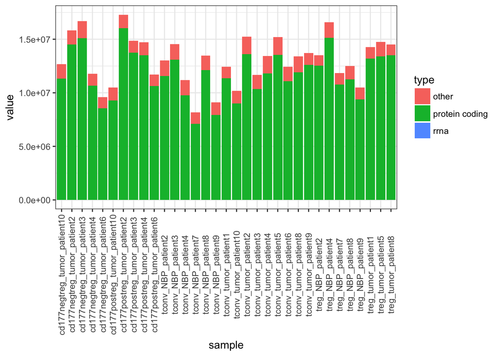

```r
proteinCoding <- mart[mart[, 3] == "protein_coding", ]
rRNA <- mart[mart[, 3] == "rRNA", ]

pcCounts <- counts[rownames(counts) %in% as.character(proteinCoding[, 1]), ]
rrnaCounts <- counts[rownames(counts) %in% as.character(rRNA[, 1]), ]

sampleCount <- ncol(counts)
toPlot <- data.frame(
  sample=rep(colnames(counts), 3),
  value=c(colSums(counts) - colSums(pcCounts) - colSums(rrnaCounts),
          colSums(pcCounts),
          colSums(rrnaCounts)),
  type=c(rep("other", sampleCount),
         rep("protein coding", sampleCount),
         rep("rrna", sampleCount))
)

plot <- ggplot(data=toPlot, aes(x=sample, y=value, fill=type)) +
  geom_bar(stat="identity") + theme_bw() +
  theme(axis.text.x = element_text(angle=90, vjust=0.5))
plot
```

# DESeq2

DESeq2 – это царь-библиотека необходимая для работы с данными RNA-seq. Тут и дифференциальная экспрессия, и нормализации, и PCA-plots.

```r
# Tregs vs Tconv
dds <- DESeqDataSetFromMatrix(countData = counts,
                              colData = conditions,
                              design = ~ tissue + cells)
dds <- dds[rowSums(counts(dds)) > 20, ]
dds <- DESeq(dds)
vst_dds <- vst(dds)
counts.norm <- assay(vst_dds)

# Breast tumor vs Normal breat tissue
dds2 <- DESeqDataSetFromMatrix(countData = counts,
                              colData = conditions,
                              design = ~ cells + tissue)
dds2 <- dds2[rowSums(counts(dds2)) > 20, ]
dds2 <- DESeq(dds2)
vst_dds2 <- vst(dds2)
counts.norm2 <- assay(vst_dds2)
```

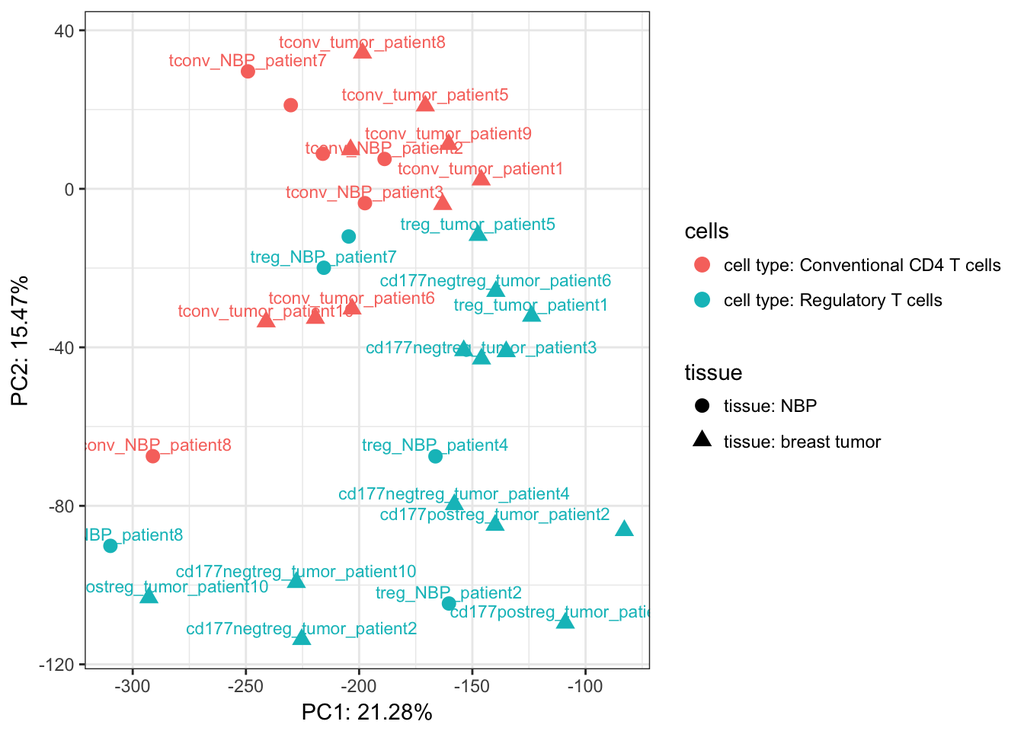

```r
pca_data <- prcomp(t(counts.norm))
percents <- pca_data$sdev^2 / sum(pca_data$sdev^2)
to_plot <- t(counts.norm) %*% pca_data$rotation

gdata <- data.frame(
  x=to_plot[, 1],
  y=to_plot[, 2],
  tissue=conditions[, 1],
  cells=conditions[, 2],
  name=rownames(conditions)
)

ggplot(data=gdata, aes(x=x, y=y, color=cells, shape=tissue, text=name)) +
  geom_point(size=3) + theme_bw()  +
  xlab(paste0("PC", 1, ": ", formatC(100 * percents[1], digits=4), "%")) +
  ylab(paste0("PC", 2, ": ", formatC(100 * percents[2], digits=4), "%")) +
  geom_text(aes(label=gdata$name), size=3, check_overlap = T, nudge_y = 3)
```

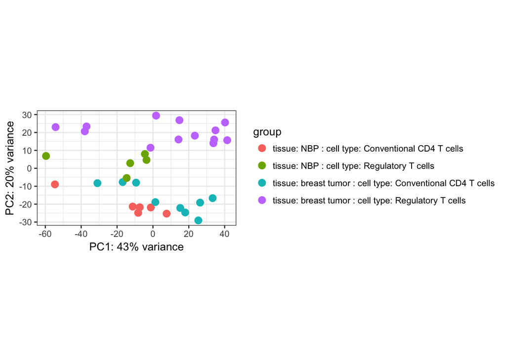

```r
plotPCA(vst_dds, intgroup=c("tissue", "cells")) + theme_bw()
```

# Differential expression

Давайте посмотрим, как выглядят результаты дифференциальной экспрессии и отсортируем их по статистике.

```r
# Tregs vs Tconv
res <- results(dds)
# res
# mcols(res)$description
res <- res[order(res[, 4]), ]

# Breast tumor vs Normal breat tissue
res2 <- results(dds2)
res2 <- res2[order(res2[, 4]), ]
```

# Volcano plot: add some colors

Самый обычный способ визуализировать данные дифф.экспрессии – это volcano plot. По оси x мы будем откладывать log fold change, а по y - adjusted p value.

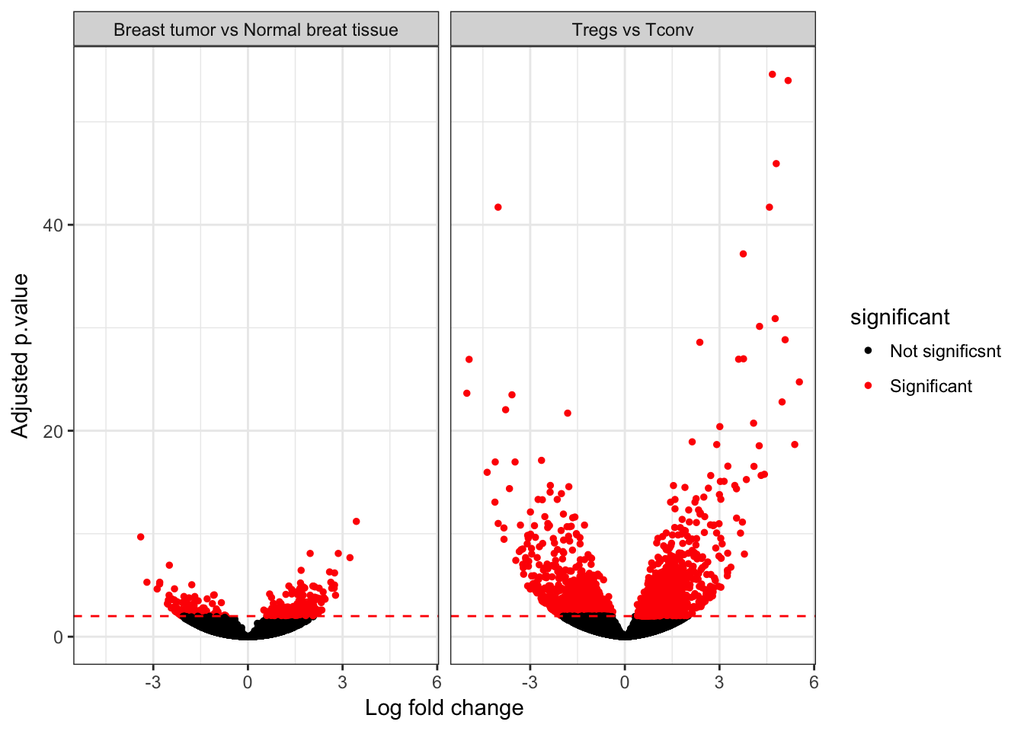

```r
# Tregs vs Tconv
gdata_l <- data.frame(
  x=res$log2FoldChange,
  y=-log10(res$padj),
  exp_type="Tregs vs Tconv"
)

# Breast tumor vs Normal breat tissue
gdata_r <- data.frame(
  x=res2$log2FoldChange,
  y=-log10(res2$padj),
  exp_type="Breast tumor vs Normal breat tissue"
)

gdata <- na.omit(rbind(gdata_r, gdata_l))
gdata$significant <- as.factor(ifelse(gdata$y > -log10(0.01), "Significant", "Not significsnt"))

ggplot(data=gdata, aes(x=x, y=y, color=significant)) +
  geom_point(size=1) + theme_bw()  +
  xlab("Log fold change") +
  ylab("Adjusted p.value") +
  facet_grid(.~exp_type) +
  geom_hline(yintercept=-log10(0.01), size = 0.5, linetype = 'dashed', colour = 'red') +
  scale_color_manual(values = c('black', 'red'))
```

Также мы можем построить тепловую карту отсортировав гены по статистике

```r
counts.norm <- counts(dds, normalized=TRUE)
png("heatmap_large.png", width=6, height=20, units="in", res=300)

to_visualise <- counts.norm[rownames(res), order(conditions[, 2])]
to_visualise <- t(apply(to_visualise, 1, function(r) {
  (r - min(r)) / (max(r) - min(r))
}))

pheatmap(to_visualise,
         show_rownames = F, cluster_rows = F,
         cluster_cols=F,
         annotation_col = conditions)
dev.off()
```

# Визуализация пасвея GO:0007159: leukocyte cell-cell adhesion

```r
kkeys <- keys(org.Hs.eg.db, keytype="ENSEMBL")
goAnno <- AnnotationDbi::select(org.Hs.eg.db, keys=kkeys,
                                keytype="ENSEMBL", columns=c("GOALL", "ONTOLOGYALL", "SYMBOL"))
```

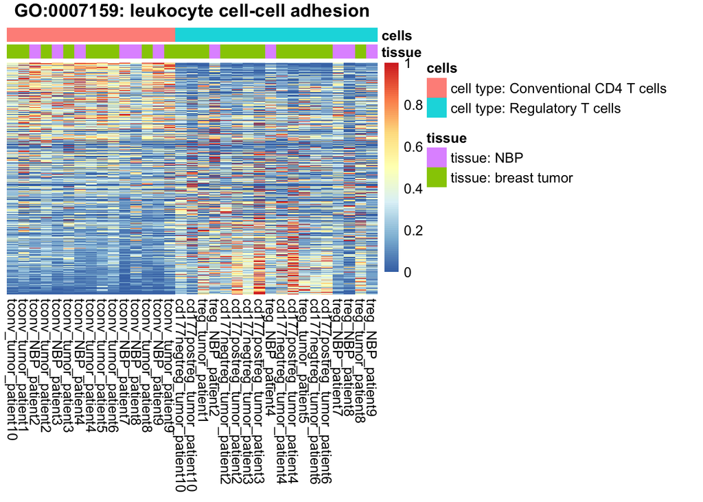

```r
goAnno <- tbl_df(goAnno)
goAnno <- filter(goAnno, GOALL=="GO:0007159")
# or you can pick ENTREZ, or SYMBOL, or whatever you want
genesToVisualise <- goAnno$ENSEMBL

path_res <- res[intersect(rownames(res), genesToVisualise), ]
path_res <- path_res[order(path_res[, 4]), ]

to_visualise <- counts.norm[rownames(path_res), order(conditions[, 2])]
to_visualise <- t(apply(to_visualise, 1, function(r) {
  (r - min(r)) / (max(r) - min(r))
}))

pheatmap(to_visualise,
         show_rownames = F, cluster_rows = F,
         cluster_cols=F,
         annotation_col = conditions,
         main = "GO:0007159: leukocyte cell-cell adhesion")
```

# Venn diagrams, genes intersections

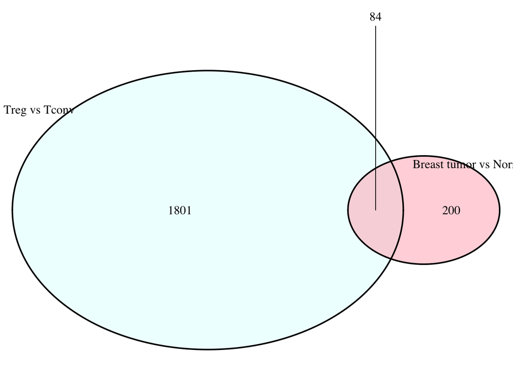

[output not shown]

```r
cells_set <- rownames(res[!is.na(res$padj) & res$padj < 0.01, ])
tissues_set <- rownames(res2[!is.na(res2$padj) & res2$padj < 0.01, ])
common_genes <- intersect(cells_set, tissues_set)

draw.pairwise.venn(length(cells_set), length(tissues_set), length(common_genes),
                   category = c("Treg vs Tconv", "Breast tumor vs Normal breat tissue"),
                   fill = c("lightcyan1", "lightpink1"))
```

# clusterProfiler

Библиотека содержит в себе большое количество утилит для аннотации наборов генов.

```r
genes <- bitr(rownames(res),
              fromType = "ENSEMBL",
              toType = c("ENTREZID", "SYMBOL"),
              OrgDb = org.Hs.eg.db)
head(genes)
```

```
##            ENSEMBL ENTREZID SYMBOL
## 2  ENSG00000113088     3003   GZMK
## 4  ENSG00000026751    57823 SLAMF7
## 6  ENSG00000133302    84250   SLF1
## 7  ENSG00000164398    23305  ACSL6
## 8  ENSG00000145649     3001   GZMA
## 10 ENSG00000100450     2999   GZMH
```

```r
genes <- genes[!duplicated(genes[, 1]), ]
rownames(genes) <- genes[, 1]
res$ENSEMBL <- rownames(res)

merged <- merge(as.data.frame(res), genes)
head(merged)
```

```
##           ENSEMBL   baseMean log2FoldChange     lfcSE       stat       pvalue         padj ENTREZID   SYMBOL
## 1 ENSG00000000003 423.163296     0.63538194 0.4920649  1.2912563 1.966148e-01 4.115223e-01     7105   TSPAN6
## 2 ENSG00000000005   8.893115    -0.14072864 0.5653426 -0.2489263 8.034178e-01 9.019086e-01    64102     TNMD
## 3 ENSG00000000419 848.545987     0.19179247 0.1553810  1.2343366 2.170775e-01 4.367093e-01     8813     DPM1
## 4 ENSG00000000457 418.002766    -0.20724424 0.2863086 -0.7238491 4.691584e-01 6.782815e-01    57147    SCYL3
## 5 ENSG00000000460 255.889945     1.03038790 0.2109222  4.8851554 1.033473e-06 5.029307e-05    55732 C1orf112
## 6 ENSG00000000938  31.380430     0.05804886 0.5780237  0.1004264 9.200058e-01 9.640626e-01     2268      FGR
```

Давайте что-нибудь узнаем о дифф.экспрессированных генах!

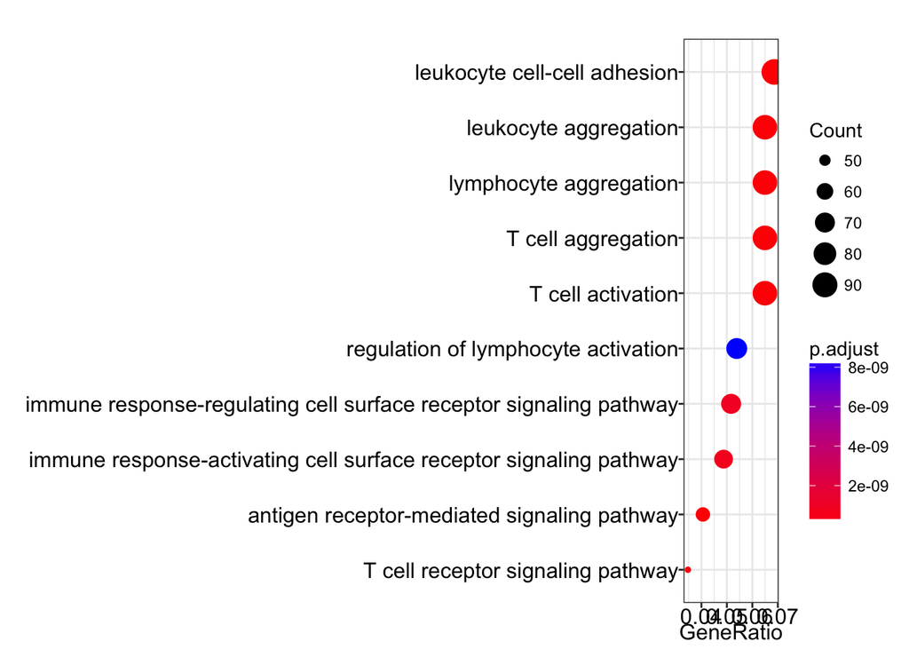

```r
diffExpGenes <- merged[which(merged$padj < 0.01), 8]
universe <- as.character(merged[, 8])

ego <- enrichGO(gene          = diffExpGenes,
                universe      = universe,
                OrgDb         = org.Hs.eg.db,
                ont           = "BP",
                pAdjustMethod = "BH",
                pvalueCutoff  = 0.01,
                qvalueCutoff  = 0.05,
        readable      = TRUE)
# head(ego)
dotplot(ego)
```